# Homework week 5

*Module 8: Homework Problem 2*

```r
f<- file.choose()
f
```

```
## [1] "C:\\Users\\Allison\\Desktop\\GitHub\\exercise1\\zombiedata.csv"
```

```r
d<- read.csv(f, sep= ",", header=T)
##this chunk of code loads the zombie file data into R
```

**Number 1** #Calculate the population mean and standard deviation for each quantitative random variable (height, weight, age, number of zombies killed, and years of education). NOTE: You will not want to use the built in var() and sd() commands as these are for samples.

```r
summary(d) ##gives me a basic idea of what I'm dealing with here, also provides way to check mean answers
```

```
##       X.2              X.1               X                id
##  Min.   :   1.0   Min.   :   1.0   Min.   :   1.0   Min.   :   1.0
##  1st Qu.: 250.8   1st Qu.: 250.8   1st Qu.: 250.8   1st Qu.: 250.8
##  Median : 500.5   Median : 500.5   Median : 500.5   Median : 500.5
##  Mean   : 500.5   Mean   : 500.5   Mean   : 500.5   Mean   : 500.5
##  3rd Qu.: 750.2   3rd Qu.: 750.2   3rd Qu.: 750.2   3rd Qu.: 750.2
##  Max.   :1000.0   Max.   :1000.0   Max.   :1000.0   Max.   :1000.0
##
##    first_name     last_name      gender        height
##  Roy    : 14   Anderson: 11   Female:494   Min.   :54.15
##  Tammy  : 12   Cook    : 10   Male  :506   1st Qu.:64.68
##  Maria  : 11   Davis   : 10                Median :67.50
##  Daniel : 10   Flores  :  9                Mean   :67.63
##  Phyllis: 10   Howell  :  9                3rd Qu.:70.38
##  Terry  : 10   Scott   :  9                Max.   :80.53
##  (Other):933   (Other) :942
##      weight       zombies_killed   years_of_education
##  Min.   : 90.29   Min.   : 0.000   Min.   :0.000
##  1st Qu.:131.81   1st Qu.: 2.000   1st Qu.:2.000
##  Median :142.89   Median : 3.000   Median :3.000
##  Mean   :143.91   Mean   : 2.992   Mean   :2.996
##  3rd Qu.:156.28   3rd Qu.: 4.000   3rd Qu.:4.000
##  Max.   :210.79   Max.   :11.000   Max.   :8.000
##
##                              major          age
##  criminal justice administration: 50   Min.   :10.66
##  physical education             : 50   1st Qu.:18.07
##  psychology                     : 46   Median :19.90
##  medicine/nursing               : 45   Mean   :20.05
##  pharmacology                   : 44   3rd Qu.:21.94
##  environmental science          : 43   Max.   :29.59
##  (Other)                        :722
```

```r
sdv<- function(x){sqrt(sum((x-mean(x))^2)/length(x))} ##created a function for the standard deviation, could not use var() because it would have divided by the wrong length

mean(d$height, na.rm = T)
```

```
## [1] 67.6301
```

```r
sdv(d$height)
```

```
## [1] 4.30797
```

```r
mean(d$weight, na.rm = T)
```

```
## [1] 143.9075
```

```r
sdv(d$weight)
```

```
## [1] 18.39186
```

```r
mean(d$age, na.rm = T)
```

```
## [1] 20.04696
```

```r
sdv(d$age)
```

```
## [1] 2.963583
```

```r
mean(d$zombies_killed, na.rm = T)
```

```
## [1] 2.992
```

```r
sdv(d$zombies_killed)
```

```
## [1] 1.747551
```

```r
mean(d$years_of_education, na.rm = T)
```

```
## [1] 2.996
```

```r
sdv(d$years_of_education)
```

```
## [1] 1.675704
```

**Number 2** #Use ggplot and make boxplots of each of these variable by gender.

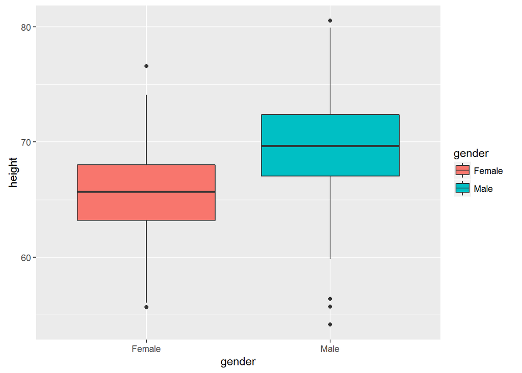

```r
library(ggplot2)
ggplot(d, aes(x=gender, y=height, fill=gender))+geom_boxplot()
```

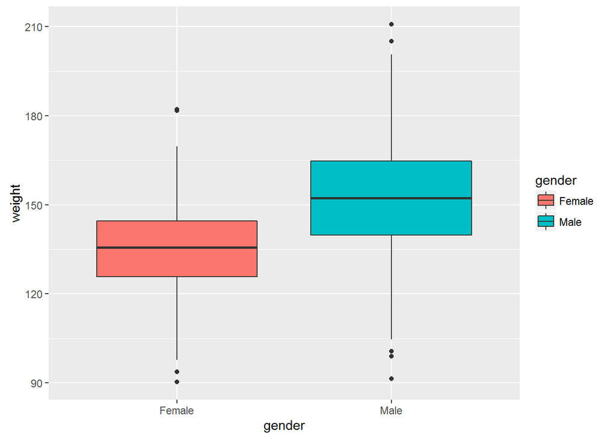

```r
ggplot(d, aes(x=gender, y=weight, fill=gender))+geom_boxplot()
```

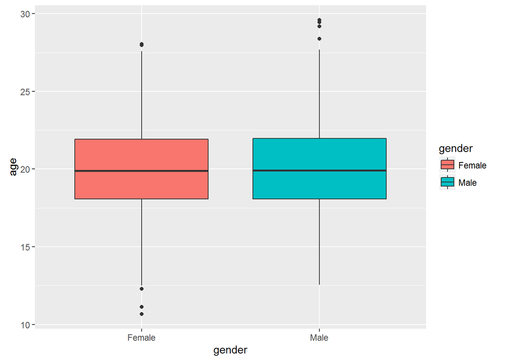

```r
ggplot(d, aes(x=gender, y=age, fill=gender))+geom_boxplot()
```

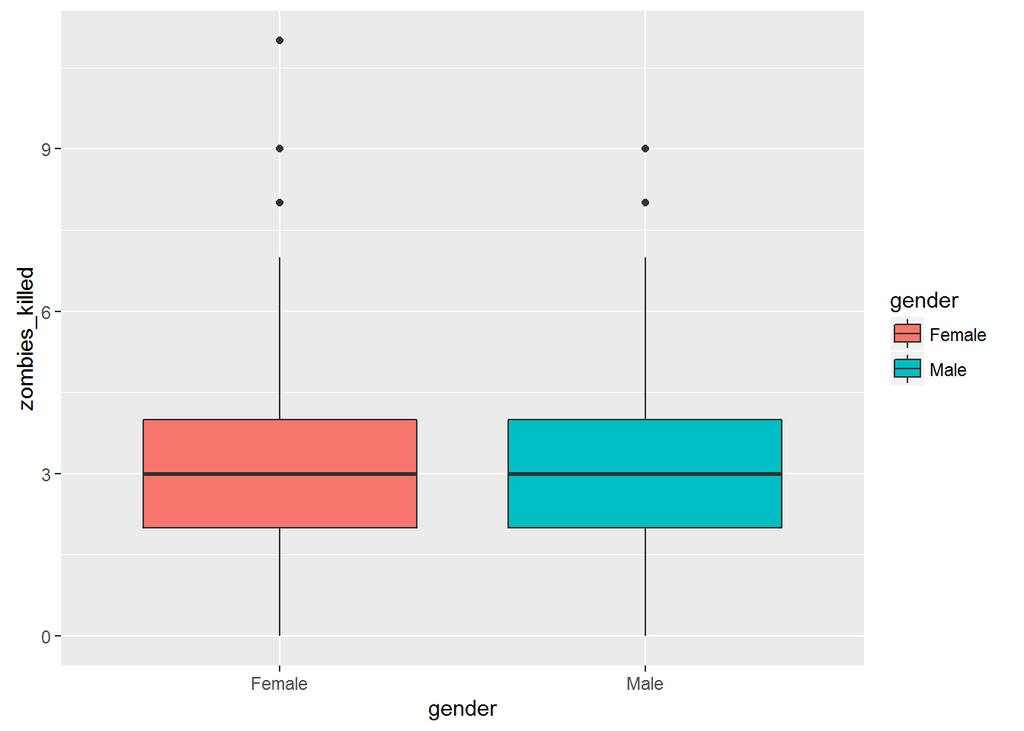

```r
ggplot(d, aes(x=gender, y=zombies_killed, fill=gender))+geom_boxplot()
```

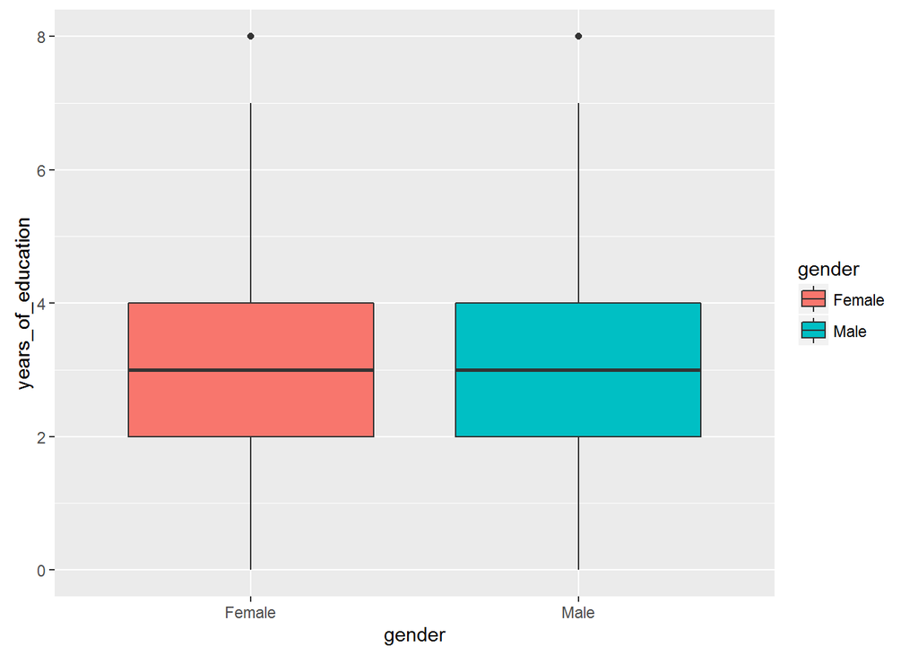

```r
ggplot(d, aes(x=gender, y=years_of_education, fill=gender))+geom_boxplot()
```

**Number 3** #Use ggplot and make a scatterplots of height and weight in relation to age. Do these variables seem to be related? In what way?

```r
gh<- ggplot(d, aes(x=age, y=height))+geom_point() ##I put age on the x axis because this makes it easier for me to compare the two different scatterplots
gw<- ggplot(d, aes(x=age, y=weight))+geom_point()
#Both height and weight are both positively correlated with age, with height being more closely correlated with weight varying.  More fat young people than tall young people.
```

[output not shown]

**Number 4** #Using histograms and Q-Q plots, check whether the quantitative variables seem to be drawn from a normal distribution. Which seem to be and which do not (hint: not all are drawn from the normal distribution)? For those that are not, can you determine what common distribution they are drawn from?

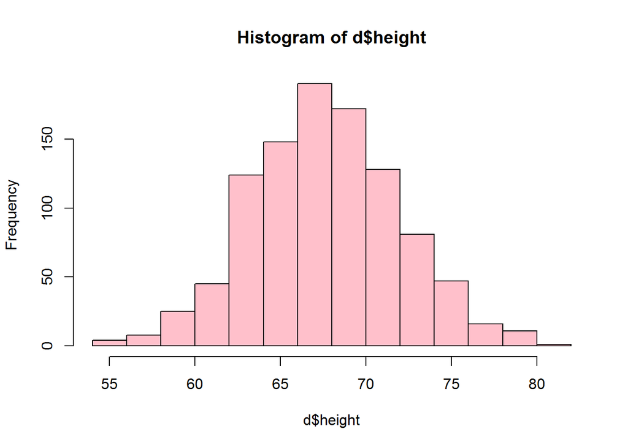

```r
hh<-hist(d$height, col="pink")
```

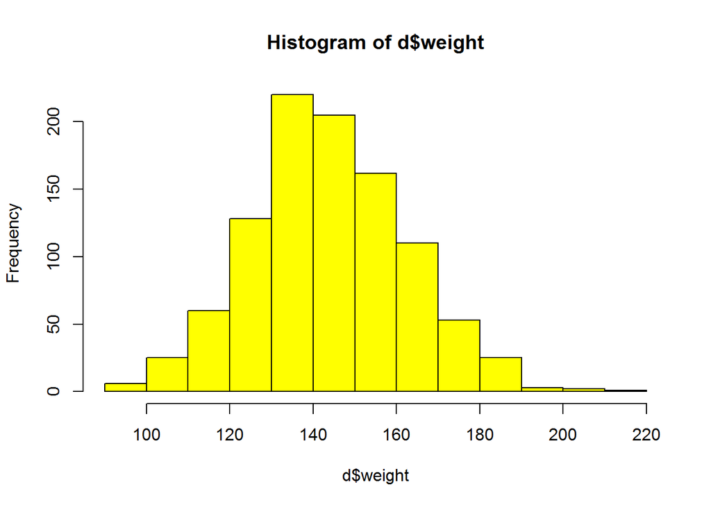

```r
hd<- hist(d$weight, col="yellow")
```

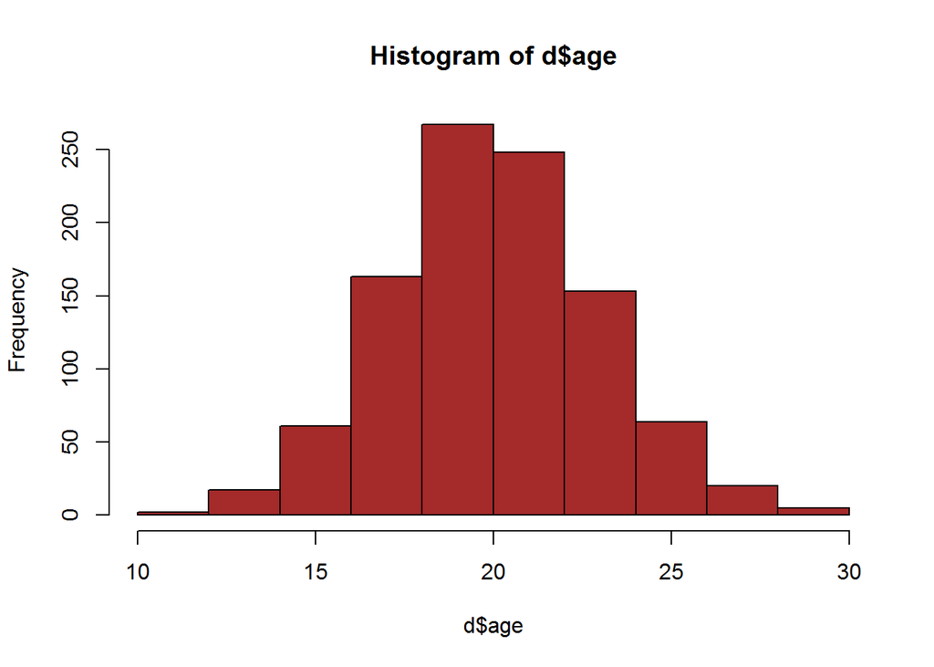

```r
ha<- hist(d$age, col="brown") ###don't be fooled, this is more of a burnt adobe color
```

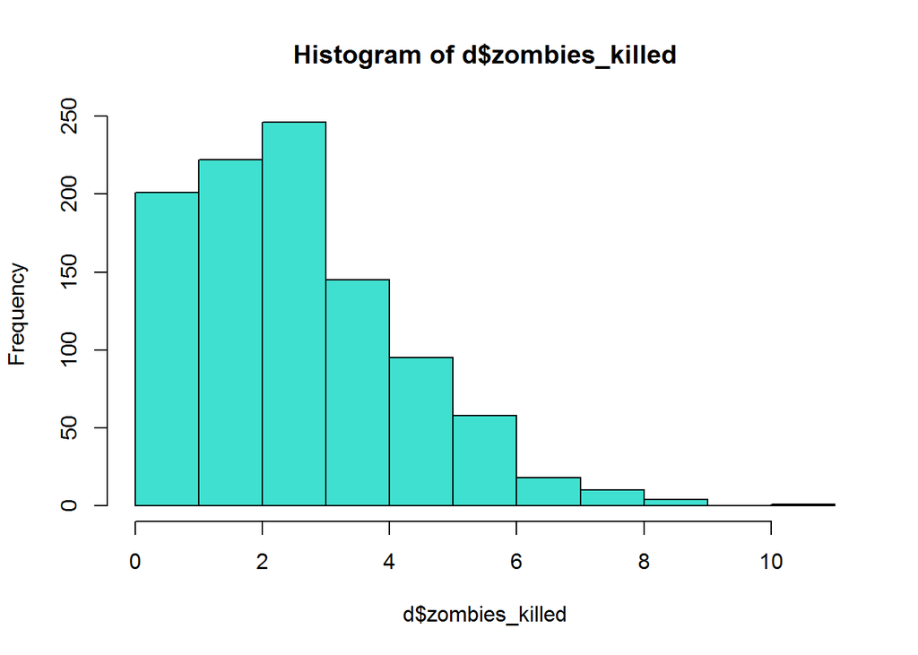

```r
hz<- hist(d$zombies_killed, col="turquoise")
```

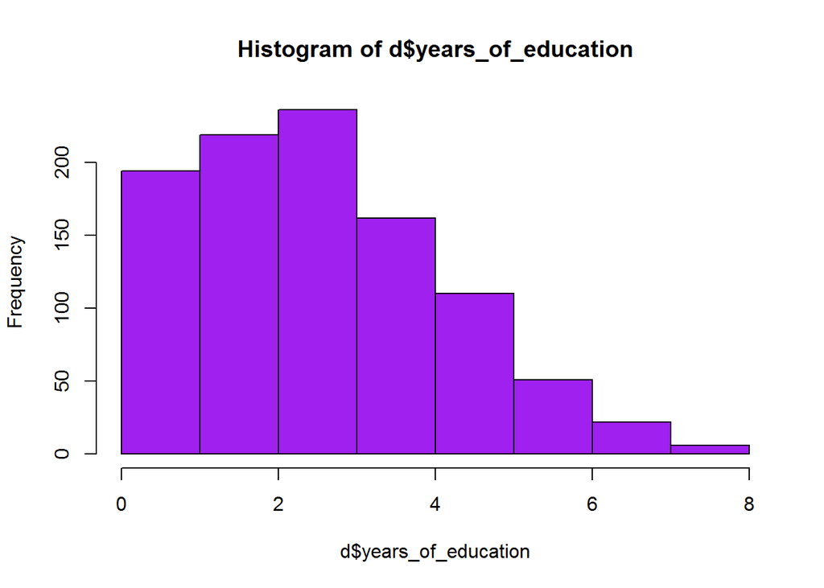

```r
hy<- hist(d$years_of_education, col="purple")
```

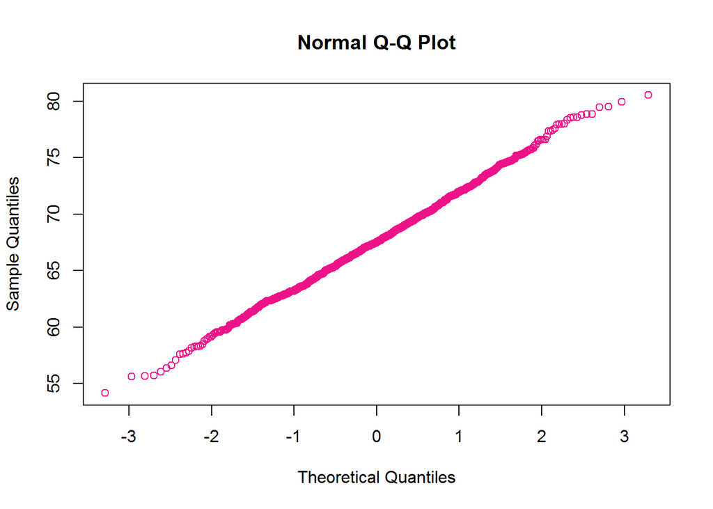

```r
qh<- qqnorm(d$height, col="deeppink2")
```

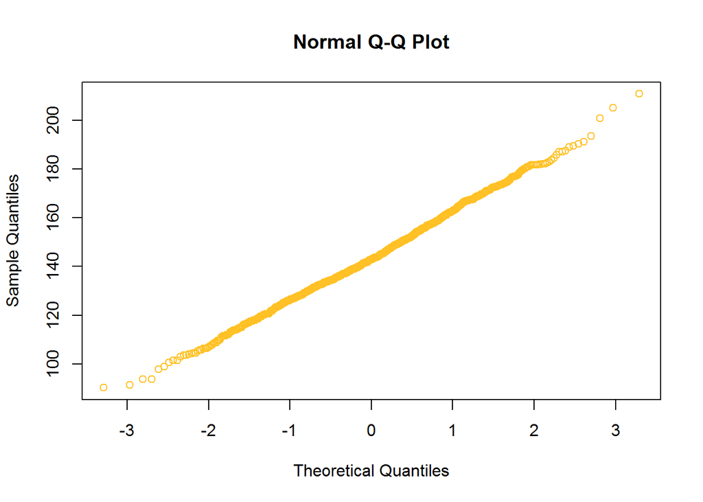

```r
qw<-qqnorm(d$weight, col="goldenrod1")
```

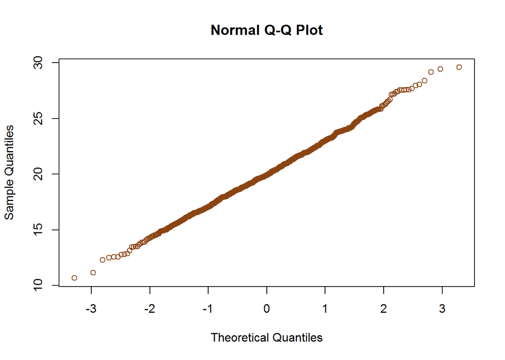

```r
qa<- qqnorm(d$age, col="saddlebrown")
```

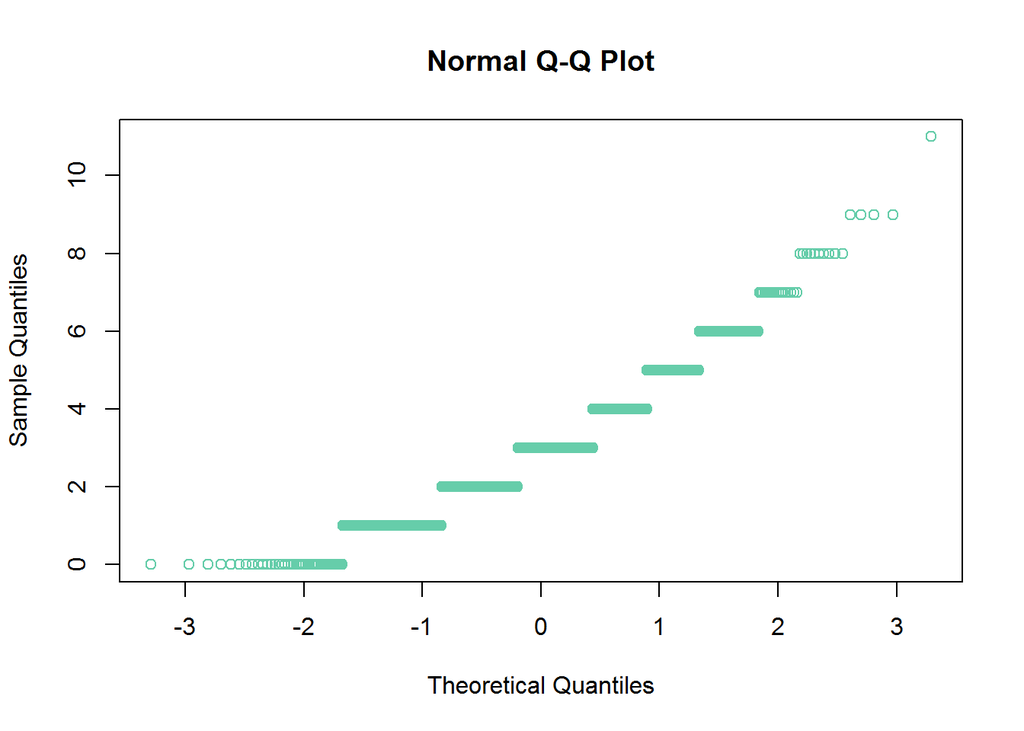

```r
qz<- qqnorm(d$zombies_killed, col="mediumaquamarine")
```

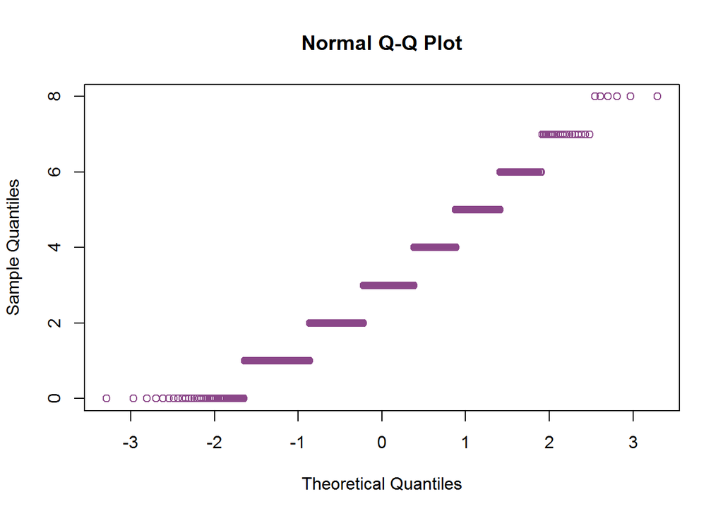

```r
qy<-qqnorm(d$years_of_education, col= "orchid4")
```